# Assignment3

Stewart Green, Chris Walsh, Leisha Parkinson

1/1/2022

# Executive Summary

The project team has analysed and developed predictive analysis models for a dataset provided by Petrfinder.my (Malaysia’s largest online database for rehoming household pets). We shall develop models using clustering, classification and regression approaches. Our overall objective is to provide data insights and offer business advice for the application of our models.

# Introduction

The dataset will shall analyse comes from PetFinder.my website. Set up since 2008, they have over 150,000 on their database and lead the way in animal welfare in Malaysia, helping pets get adopted to loving homes.

PetFinder exists in several countries, but is very important in Malaysia where pets are common but strays are increasing. Here are some interesting facts.

- Almost 60% of homes in Malaysia have pets, 20% are dog owners;
- Stray animals in Malaysia are on the rise; and
- In 2021, there was an increase of almost 300% in pet abandonment.

# 1. Initial data import and review

The dataset includes four (4) .csv files. The main file is `train.csv`; it is called ‘train’ because it was originally part of a Kaggle Competition which holds back the testing dataset for evaluation of the entries. For our purposes, we shall use this as our full dataset and set to the variable ‘data’.

| File | Description | Variable |
| --- | --- | --- |
| `train.csv` | Main dataset to be used | data |

In addition to the main dataset, the following files were imported and saved to variables in R.

| File | Description | Variable |
| --- | --- | --- |
| `PetFinder-BreedLabels.csv` | Breed ID and description | breed |
| `PetFinder-ColourLabels.csv` | Colour ID and description | colour |
| `PetFinder-StateLabels.csv` | State ID and description | state |

Please see below summary of ‘data’ using skimr package.

Data summary

| Name | data |
| --- | --- |
| Number of rows | 14993 |
| Number of columns | 24 |
| _______________________ |  |
| Column type frequency: |  |
| character | 4 |
| numeric | 20 |
| ________________________ |  |
| Group variables | None |

**Variable type: character**

| skim_variable | n_missing | complete_rate | min | max | empty | n_unique | whitespace |
| --- | --- | --- | --- | --- | --- | --- | --- |
| Name | 0 | 1 | 0 | 84 | 1257 | 9061 | 0 |
| RescuerID | 0 | 1 | 32 | 32 | 0 | 5595 | 0 |
| Description | 0 | 1 | 1 | 6664 | 0 | 14033 | 0 |
| PetID | 0 | 1 | 9 | 9 | 0 | 14993 | 0 |

**Variable type: numeric**

| skim_variable | n_missing | complete_rate | mean | sd | p0 | p25 | p50 | p75 | p100 | hist |
| --- | --- | --- | --- | --- | --- | --- | --- | --- | --- | --- |
| Type | 0 | 1 | 1.46 | 0.50 | 1 | 1 | 1 | 2 | 2 | ▇▁▁▁▇ |
| Age | 0 | 1 | 10.45 | 18.16 | 0 | 2 | 3 | 12 | 255 | ▇▁▁▁▁ |
| Breed1 | 0 | 1 | 265.27 | 60.06 | 0 | 265 | 266 | 307 | 307 | ▁▁▁▁▇ |
| Breed2 | 0 | 1 | 74.01 | 123.01 | 0 | 0 | 0 | 179 | 307 | ▇▁▁▁▂ |
| Gender | 0 | 1 | 1.78 | 0.68 | 1 | 1 | 2 | 2 | 3 | ▆▁▇▁▂ |
| Color1 | 0 | 1 | 2.23 | 1.75 | 1 | 1 | 2 | 3 | 7 | ▇▁▁▁▁ |
| Color2 | 0 | 1 | 3.22 | 2.74 | 0 | 0 | 2 | 6 | 7 | ▇▆▃▂▇ |
| Color3 | 0 | 1 | 1.88 | 2.98 | 0 | 0 | 0 | 5 | 7 | ▇▁▁▁▃ |
| MaturitySize | 0 | 1 | 1.86 | 0.55 | 1 | 2 | 2 | 2 | 4 | ▂▇▁▁▁ |
| FurLength | 0 | 1 | 1.47 | 0.60 | 1 | 1 | 1 | 2 | 3 | ▇▁▅▁▁ |
| Vaccinated | 0 | 1 | 1.73 | 0.67 | 1 | 1 | 2 | 2 | 3 | ▆▁▇▁▂ |
| Dewormed | 0 | 1 | 1.56 | 0.70 | 1 | 1 | 1 | 2 | 3 | ▇▁▅▁▂ |
| Sterilized | 0 | 1 | 1.91 | 0.57 | 1 | 2 | 2 | 2 | 3 | ▂▁▇▁▂ |
| Health | 0 | 1 | 1.04 | 0.20 | 1 | 1 | 1 | 1 | 3 | ▇▁▁▁▁ |
| Quantity | 0 | 1 | 1.58 | 1.47 | 1 | 1 | 1 | 1 | 20 | ▇▁▁▁▁ |
| Fee | 0 | 1 | 21.26 | 78.41 | 0 | 0 | 0 | 0 | 3000 | ▇▁▁▁▁ |
| State | 0 | 1 | 41346.03 | 32.44 | 41324 | 41326 | 41326 | 41401 | 41415 | ▇▁▁▁▃ |
| VideoAmt | 0 | 1 | 0.06 | 0.35 | 0 | 0 | 0 | 0 | 8 | ▇▁▁▁▁ |
| PhotoAmt | 0 | 1 | 3.89 | 3.49 | 0 | 2 | 3 | 5 | 30 | ▇▁▁▁▁ |
| AdoptionSpeed | 0 | 1 | 2.52 | 1.18 | 0 | 2 | 2 | 4 | 4 | ▁▆▇▆▇ |

# 2. Data pre-processing

Before we begin our deeper analysis and development of models, we must first look closely at the dataset and perform any necessary pre-processing.

## 2.1 `Type` of animal

There are a total of 14,993 observations in the ‘data’ dataset, consisting of only dogs and cats. We can reasonably expect there to be an inherent difference between the species, and for this reason we have chosen to look specifically at dogs.

## 2.2 `AdoptionSpeed`

The data has an ‘AdoptionSpeed’ for each dog, ranging from 0 (adopted on the same day as posting) to 4 (not adopted), as per below.

0 - Pet was adopted on the same day as it was listed.  
1 - Pet was adopted between 1 and 7 days (1st week) after being listed.  
2 - Pet was adopted between 8 and 30 days (1st month) after being listed.  
3 - Pet was adopted between 31 and 90 days (2nd & 3rd month) after being listed.  
4 - No adoption after 100 days of being listed. (There are no pets in this dataset that waited between 90 and 100 days).

| AdoptionSpeed | n |
| --- | --- |
| 0 | 170 |
| 1 | 1435 |
| 2 | 2164 |
| 3 | 1949 |
| 4 | 2414 |

We consider it more important than the speed, was whether the dog was adopted or not. We have therefore decided to create a new variable (binary Yes/No) as per below. We will later remove variable `AdoptionSpeed` from the dataset.

**Comment:** We will later remove variable `AdoptionSpeed` from the dataset.

Distribution of new `Adopted` variable below.

| Adopted | n |
| --- | --- |
| No | 2414 |
| Yes | 5718 |

## 2.3 `Breed1` and `Breed2`

Our analysis revealed a very high proportion of dogs as Breed 307 (mixed breed) and smaller numbers of purebred/known breeds. We have therefore decided to add a new variable, simply denoting whether the dog is a purebred (or known breed) or mixed (or unknown).

| Breed | n |
| --- | --- |
| Mixed | 5923 |
| Purebred | 2209 |

**Comment:** We will later remove variables `Breed1` and `Breed2` from the dataset.

## 2.4 `Fee`

Our analysis revealed a very high proportion of dogs listed for free (i.e. no fee). The remaining dogs had a wide variety of price, therefore we decided to create a new variable `FeePayable` to simply denote whether a fee is charged or not.

| FeePayable | n |
| --- | --- |
| No | 6941 |
| Yes | 1191 |

**Comment:** We will later remove variable `Fee` from the dataset.

## 2.5: Remove unnecessary variables

We now remove the following variables from the full dataset.

| Variable | Description |
| --- | --- |
| `Type` | Removed as part of pre-processing (Sec 2.1) |
| `Name` | Name of pet (considered unnecessary to keep) |
| `RescuerID` | ID of rescuer (considered unnecessary to keep) |
| `Description` | Pet desciption (considered unnecessary to keep) **(a)** |
| `PetID` | ID of Pet (considered unnecessary to keep |
| `AdoptionSpeed` | Removed as part of pre-processing (Sec 2.2) |
| `Breed1` | Removed as part of pre-processing (Sec 2.3) |
| `Breed2` | Removed as part of pre-processing (Sec 2.3) |
| `Fee` | Removed as part of pre-processing (Sec 2.4) |

**(a)** this variable could be useful in other types of analysis, such as text mining.

## 2.6: Convert numeric to factors

We can observe that many variables are actually factors, but are listed as numeric variables. We now mutate these to become factors.

# 3.0 **Clustering:** Age of pets

We shall now explore the age of pets in more detail, and use clustering to develop a new variable in the dataset.

Please note, the ‘age’ listed for each pet represents the age in months at the date of listing.

## 3.1 Exploration of `Age` data

The distribution of age over our dataset is positively skewed where the mean is higher than the median. The average age variable in our dataset is 12.91 months, while this median age is 3. This is consistent with unwanted young animals being abandoned, as the median shows us that 50 % of animals put up for adoption are 3 months or less in age.

Also, we can observe that each 12 months there is a considerable spike in occurences (n). This is likely because users will estimate age in years, and then convert to months (i.e. multiply by 12).

Initially, we believed the age variable would be very useful in a regression analysis, however now consider clustering should be explored.

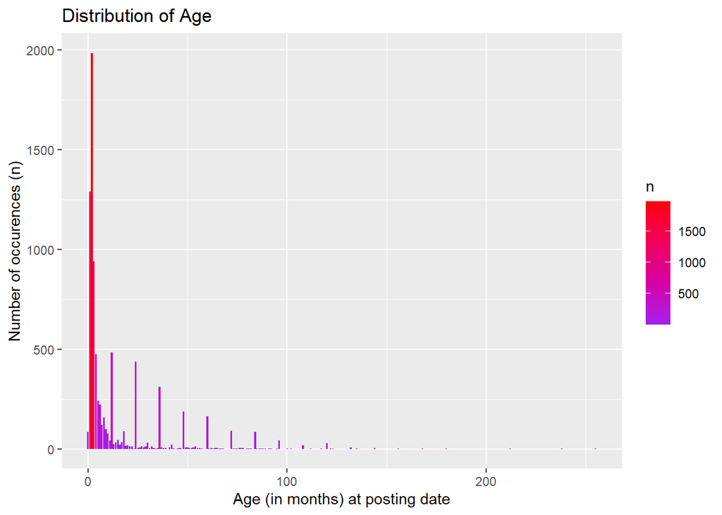

## 3.2 Perform ‘kmeans’ cluster analysis

We shall now perform ‘kmeans’ analysis of the age data. Essentially, for a range of different cluster sizes we shall analysis how closely the data ‘belongs’ to a particular group.

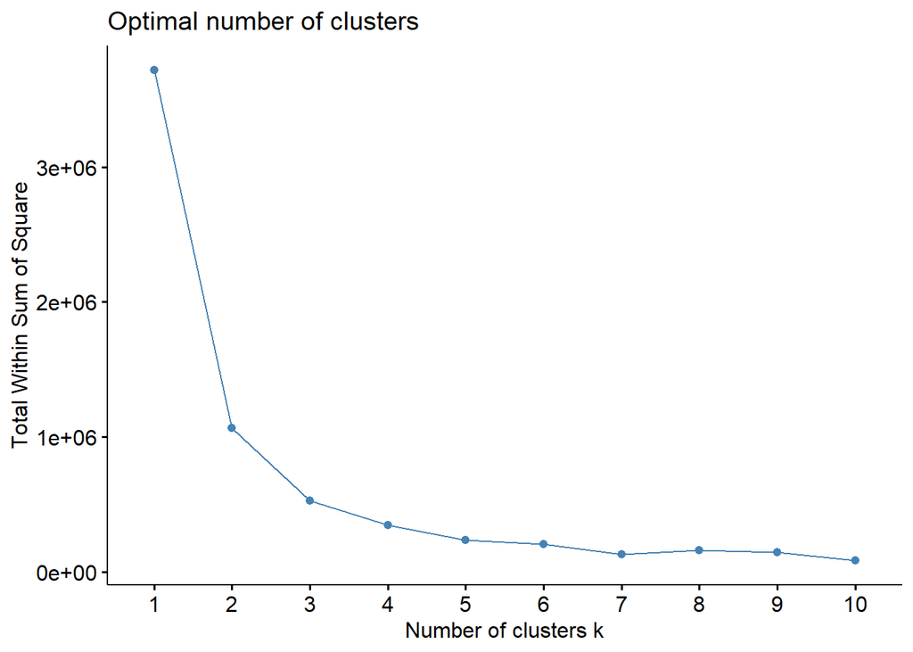

## 3.3 Apply kmeans clustering to dataset (k=4)

We observe that the optimal number of clusters (groups) is 4. Although the fit improves as the number of clusters incresaes above 4, this is only marginal.

The below table shows the mean number (in months) for each cluster. Each observation in the dataset will now have an `Age_cluster` assigned.

```
##        Age
## 1  2.49365
## 2 12.32121
## 3 33.66608
## 4 79.96130
```

## 3.4 Add name to cluster to provide meaning

We shall now apply a more understable name to the clusters, as per below.

| Cluster | Mean age of cluster | `Age_cluster` name |
| --- | --- | --- |
| 1 | 2.49365 | Puppy |
| 2 | 12.32121 | One Year |
| 3 | 33.66608 | Young |
| 4 | 79.96130 | Old |

## 3.5 Visualise observations (count) per cluster

We can see that puppy cluster has substantially more observations than the other clusters, this is consistent with early analysis of the age variable.

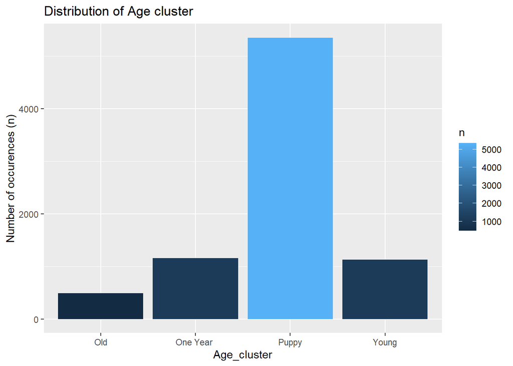

# 4. Data visualisation

### 4.1 Visualisation of selected variables

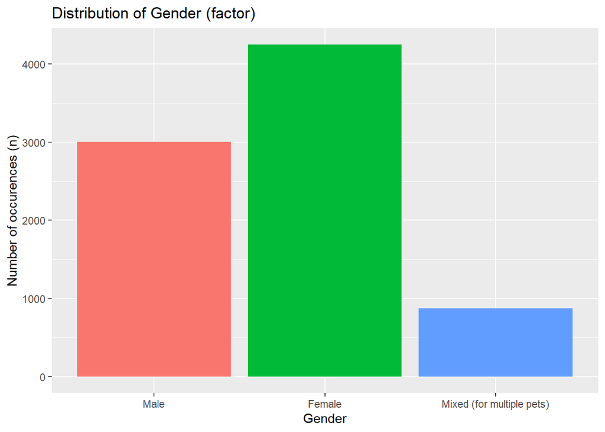

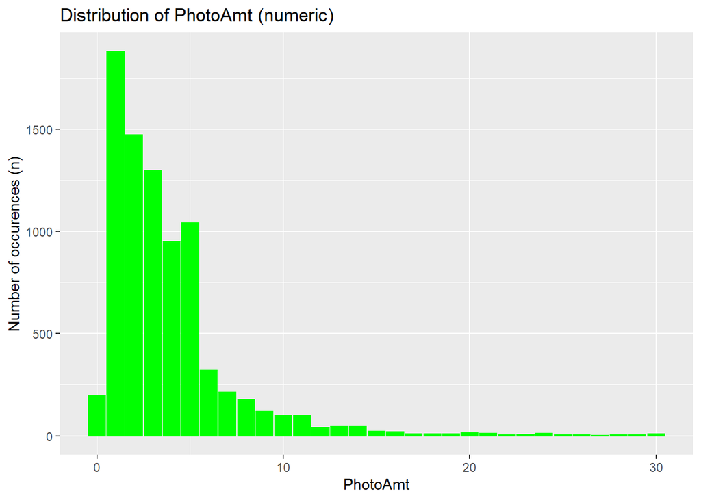

**Comment:** This variable shows us the total amount of photos uploaded for each pet. The average amount of photos per pet is 3.71, while the mean is 3. Out of the 8132 observations in this dataset, only 194 animals have no picture attached to their adoption profile.

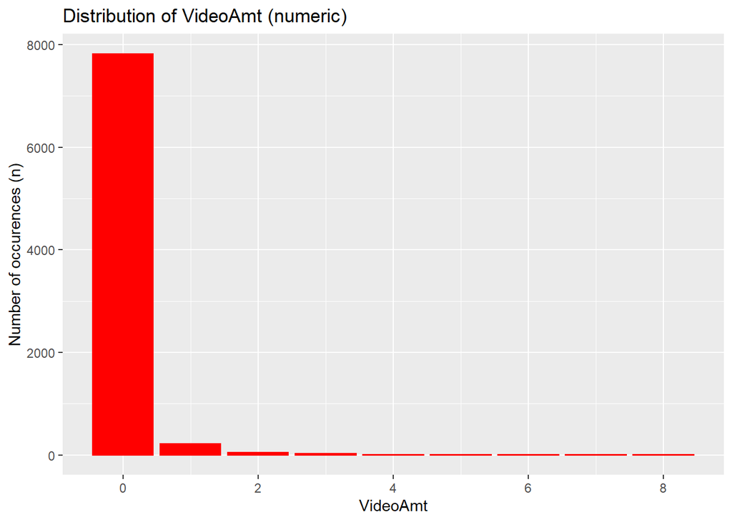

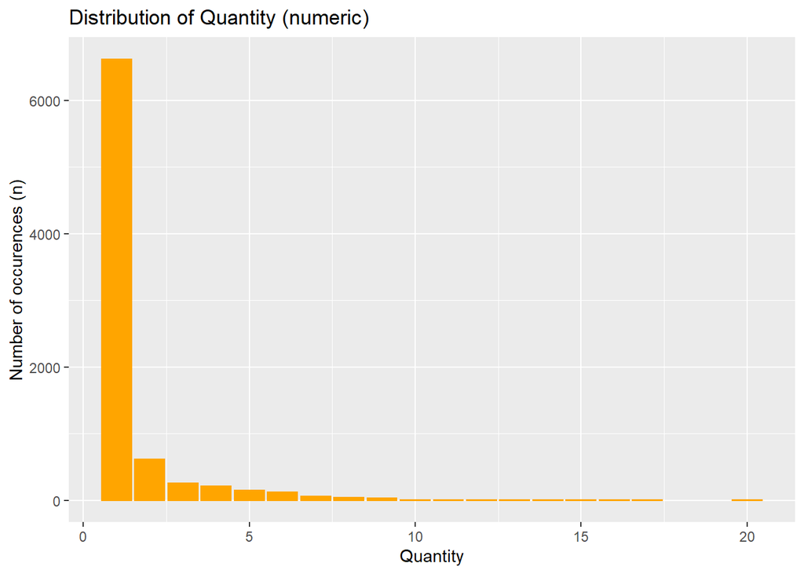

**Comment:** This variable shows us the number of pets available for adoption in a particular listing. The majority of listings are for a single pet, but some include multiple pets (e.g. a litter of cats). Where different genders are present, this is reflected in the `gender` variable.

## 4.2 Correlation

The below correlation matrix shows the level of correlation between the variables. We can observe that the darker a colour (red or blue) the higher the correlation between the variables.

This will assist us in determining which variables to include as predictor variables in our models. It is important that predictor variables are ‘independent’ therefore those with a strong correlation should not be included.

For example, we can observe a strong correlation between `Vaccinated`, `Dewormed` and `Sterilized`. We shall therefore only include one of these variables in our model.

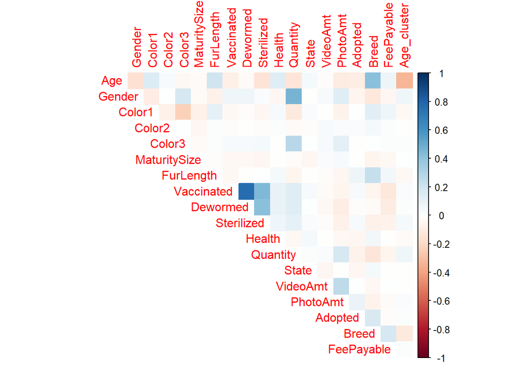

# 5.0 Data split

## 5.1 Set up training vs testing datasets

We shall now ‘split’ the dataset into a training dataset (80% of data) and a testing (20% of data). The training data will be used to train our models and once finalised, we will apply this to the testing data to evaluate metrics.

# 6.0 Classification Models

We shall now address a key business problem; can we predict whether or not a dog will be adopted based on the data provided by rescuer. As the outcome is binary (i.e. Yes/No) we should use classification models.

## 6.1 Set up recipe

We shall now define the recipe. Please note the same recipe will be used for both models.

```
## Recipe
##
## Inputs:
##
##       role #variables
##    outcome          1
##  predictor         18
##
## Operations:
##
## Delete terms Age
## Delete terms Dewormed
## Delete terms Sterilized
## Delete terms State
## Up-sampling based on FeePayable
## Up-sampling based on Breed
## Dummy variables from all_nominal_predictors()
```

**Comment:** Although good practice to use ‘prep()’ and ‘bake()’, I have not included because this is done automatically as part of workflow.

## 6.2 Set up models

We shall now set the two different models, using specific engines (both classification, of course) as per below.

**Logistic regression**

```
## Logistic Regression Model Specification (classification)
##
## Computational engine: glm
```

**Random Forest**

```
## Random Forest Model Specification (classification)
##
## Main Arguments:
##   mtry = 5
##   trees = 500
##
## Computational engine: randomForest
```

## 6.3 Set up workflow

We now create a workflow for each model type, combining the recipe and model.

**Logistic regression**

```
## == Workflow ====================================================================
## Preprocessor: Recipe
## Model: logistic_reg()
##
## -- Preprocessor ----------------------------------------------------------------
## 7 Recipe Steps
##
## * step_rm()
## * step_rm()
## * step_rm()
## * step_rm()
## * step_upsample()
## * step_upsample()
## * step_dummy()
##
## -- Model -----------------------------------------------------------------------
## Logistic Regression Model Specification (classification)
##
## Computational engine: glm
```

**Random Forest**

```
## == Workflow ====================================================================
## Preprocessor: Recipe
## Model: rand_forest()
##
## -- Preprocessor ----------------------------------------------------------------
## 7 Recipe Steps
##
## * step_rm()
## * step_rm()
## * step_rm()
## * step_rm()
## * step_upsample()
## * step_upsample()
## * step_dummy()
##
## -- Model -----------------------------------------------------------------------
## Random Forest Model Specification (classification)
##
## Main Arguments:
##   mtry = 5
##   trees = 500
##
## Computational engine: randomForest
```

## 6.4 Fit the model

We must now ‘fit’ the model to the training dataset, creating a new object for each model type.

## 6.5 Analyse variable importance

The below charts show the most important variables in each of the models, from most important at the top. We can see many variables are similar, however their rank and relative importance differs. This demonstrates the models operate quite differently, and it will be interesting to evaluate their performance late.

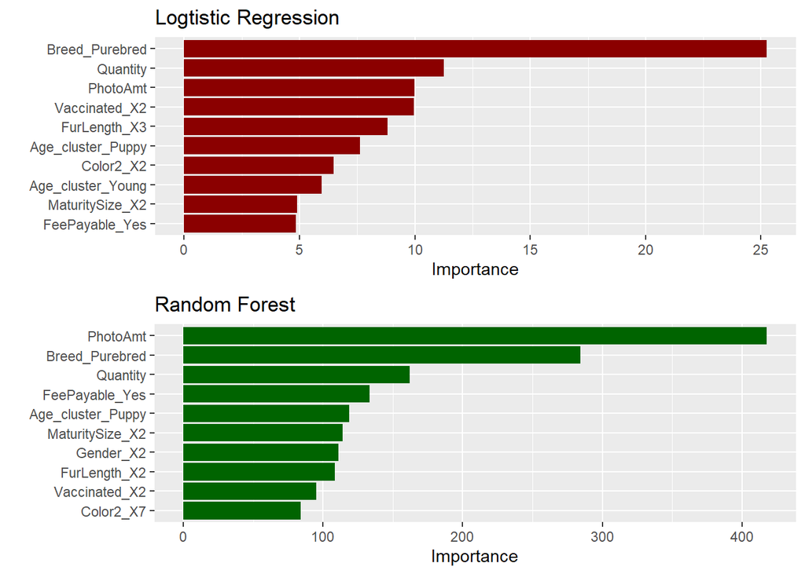

## 6.6 Run model on test data

We now run the fitted models on the test data.

## 6.7 Confusion Matrix

The below confusion matricies show the performance of each model against the test (holdout) data.

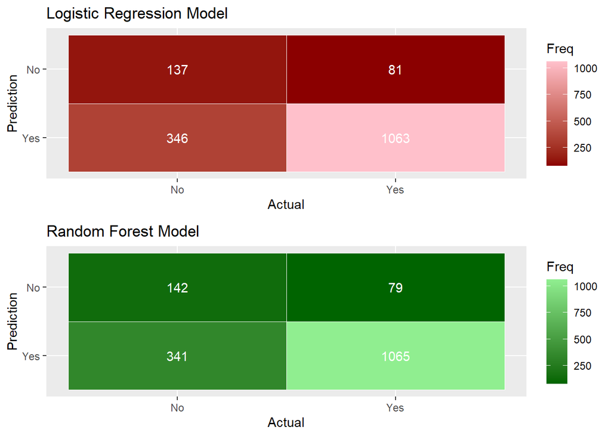

**Comment:** Despite the variables in each model differing in terms of rank and relative importance, we can see very similar results predicted against the test data. The Random Forest model, however, does perform marginally better than Logistic Regression.

## 6.8 ROC curve

We shall now create a ROC curve for each model to visualise the performance of the models, specifically the sensitivity vs specificity.

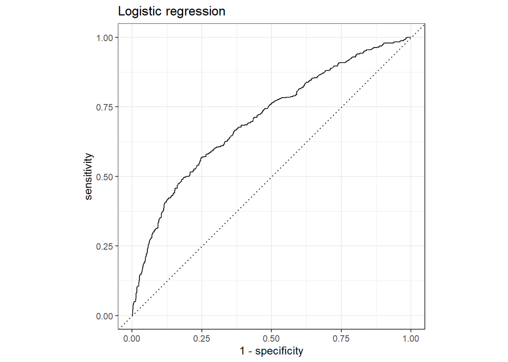

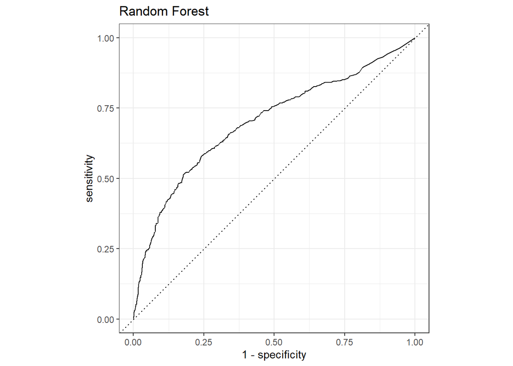

| Model | Accuracy | ROC_AUC |
| --- | --- | --- |
| Logistic Regression | 0.7375538 | 0.7039899 |
| Random Forests | 0.7418562 | 0.6995278 |

## 6.9 Summary of classification models

A possible application of this model is to inform the rescuer of the potential likelihood the pet will be adopted. This may help to set expectations and improve overall outcomes.

# 7.0 Regression Model: Boosted Trees

We shall now determine whether we can predict a numeric variable, specifically the age of pet (in months). While we created an additional variable for age (after clustering) the original numeric data value for age was retained in the dataset.

## 7.1 Set the recipe

```
## Recipe
##
## Inputs:
##
##       role #variables
##    outcome          1
##  predictor         18
##
## Operations:
##
## Delete terms Age_cluster
## Delete terms Dewormed
## Delete terms Sterilized
## Delete terms State
## Up-sampling based on FeePayable
## Up-sampling based on Breed
## Dummy variables from all_nominal_predictors()
```

## 7.2 Set up model

```
## Boosted Tree Model Specification (regression)
##
## Main Arguments:
##   tree_depth = tune()
##   learn_rate = tune()
##
## Computational engine: xgboost
```

## 7.3 Set up workflow

```
## == Workflow ====================================================================
## Preprocessor: Recipe
## Model: boost_tree()
##
## -- Preprocessor ----------------------------------------------------------------
## 7 Recipe Steps
##
## * step_rm()
## * step_rm()
## * step_rm()
## * step_rm()
## * step_upsample()
## * step_upsample()
## * step_dummy()
##
## -- Model -----------------------------------------------------------------------
## Boosted Tree Model Specification (regression)
##
## Main Arguments:
##   tree_depth = tune()
##   learn_rate = tune()
##
## Computational engine: xgboost
```

## 7.4 Run wrokflow on training data with various hyperparameter options (tuning)

We now run the workflow on the training data with different values for the ‘learning rate’ and ‘tree depth’. Each combination of different values will compute an error rate (RMSE) which we can evaluate to find the optimal parameters.

## 7.5 Visualise tuning results

Below is a visualisation of the tuning results.

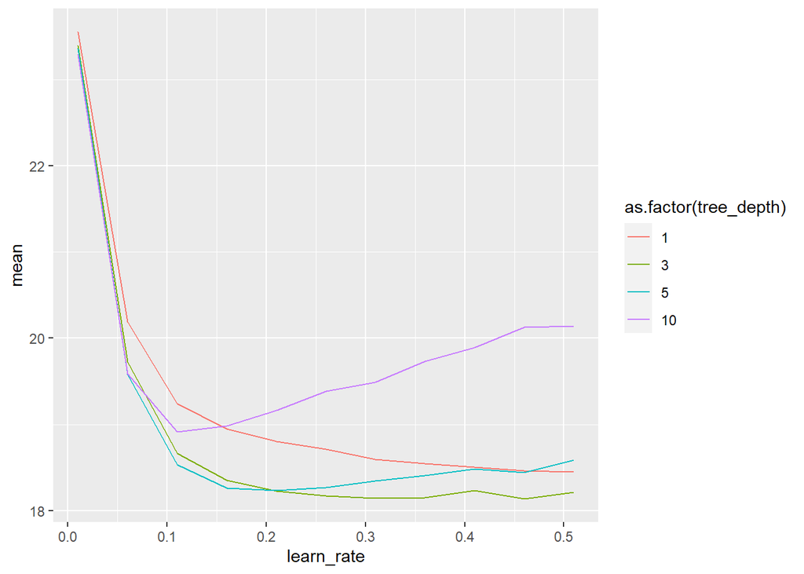

## 7.6 Select best model

We are now able to select the ‘best’ performing parameters and fit the model to the training set using these.

| tree_depth | learn_rate | .config |
| --- | --- | --- |
| 3 | 0.46 | Preprocessor1_Model21 |

## 7.7 Apply fitted model to test (holdout) data

We then run the fitted model against the test data (holdout) to determine actual performance.

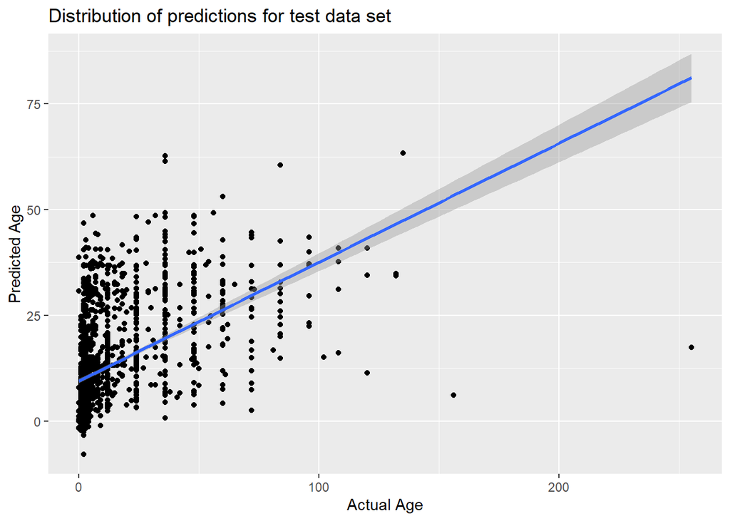

**Overall performance of model on test data**

| .metric | .estimator | .estimate |
| --- | --- | --- |
| rmse | standard | 18.10136 |

## 7.8 Evaluation of regression model

By tuning the hyper-parameters in the model, we are able to select those with best performance (i.e. lowest error). Running the fitted model against the test data demonstrates a similar error rate, indicating the model is neither ‘over’ or ‘under’ fitted.

A possible application of this model would be conduct data entry checking by the rescuer (e.g. based on the other data provided, perhaps prompt the rescuer to check age if the variance is too great). However, the model has a relatively high variance so the suitability of this application will need to be fully tested.

# Project Conclusion

Overall, we consider this to be a good dataset for analysis and model development. Predictive analysis can assist in a number of ways, for instance

- help business to achieve better outcomes (more pets adopted);
- share insights with ‘PetFinder’ businesses in other countries; and
- help to drive government policy in Malaysia (and internationally) to tackle issue of stray dogs and cats.

We were pleased with the results of our models, however we consider that other variables may be useful to explore. For instance, while we considered the number of photos we did not perform specific image analysis. Given the potential adopters will look at many potential pets, the quality of the photo may be an important variable.